# FinalProject GBUS

2023-10-18

```r
loan_data<- readRDS("C:\\Users\\ashri\\Documents\\GBUS 738\\Final project\\loandata.rds")
```

```r
str(loan_data)
```

```
## Classes 'tbl_df', 'tbl' and 'data.frame':    4110 obs. of  16 variables:
##  $ loan_default        : Factor w/ 2 levels "yes","no": 1 1 2 1 2 1 1 2 2 2 ...
##  $ loan_amount         : int  35000 10000 28800 4475 3600 12800 35000 26000 5500 40000 ...
##  $ installment         : num  927 260 942 165 111 ...
##  $ interest_rate       : num  17.25 11.5 8.97 10 9.72 ...
##  $ loan_purpose        : Factor w/ 5 levels "debt_consolidation",..: 4 4 1 3 3 3 1 1 1 5 ...
##  $ application_type    : Factor w/ 2 levels "individual","joint": 1 1 1 1 1 1 1 1 1 1 ...
##  $ term                : Factor w/ 2 levels "three_year","five_year": 2 2 1 1 1 2 2 2 1 2 ...
##  $ homeownership       : Factor w/ 3 levels "mortgage","rent",..: 2 1 2 2 1 2 1 1 2 1 ...
##  $ annual_income       : num  104660 57000 160000 37000 72000 ...
##  $ current_job_years   : num  2 10 10 1 4 10 0 5 4 3 ...
##  $ debt_to_income      : num  29.41 23.79 5.96 13.82 22.68 ...
##  $ total_credit_lines  : int  27 14 35 7 35 57 34 24 12 12 ...
##  $ years_credit_history: num  15 4 17 5 11 14 22 16 9 12 ...
##  $ missed_payment_2_yr : Factor w/ 2 levels "yes","no": 2 2 2 2 2 2 2 2 2 2 ...
##  $ history_bankruptcy  : Factor w/ 2 levels "yes","no": 2 2 1 2 2 2 2 2 2 2 ...
##  $ history_tax_liens   : Factor w/ 2 levels "yes","no": 2 2 2 2 2 2 2 2 2 2 ...
```

```r
library(dplyr)
glimpse(loan_data)
```

```
## Rows: 4,110
## Columns: 16
## $ loan_default         <fct> yes, yes, no, yes, no, yes, yes, no, no, no, no, …
## $ loan_amount          <int> 35000, 10000, 28800, 4475, 3600, 12800, 35000, 26…
## $ installment          <dbl> 927.29, 259.58, 941.65, 164.99, 110.70, 389.10, 9…
## $ interest_rate        <dbl> 17.25, 11.50, 8.97, 10.00, 9.72, 20.00, 18.25, 11…
## $ loan_purpose         <fct> small_business, small_business, debt_consolidatio…
## $ application_type     <fct> individual, individual, individual, individual, i…
## $ term                 <fct> five_year, five_year, three_year, three_year, thr…
## $ homeownership        <fct> rent, mortgage, rent, rent, mortgage, rent, mortg…
## $ annual_income        <dbl> 104660, 57000, 160000, 37000, 72000, 73000, 16700…
## $ current_job_years    <dbl> 2, 10, 10, 1, 4, 10, 0, 5, 4, 3, 10, 10, 5, 10, 1…
## $ debt_to_income       <dbl> 29.41, 23.79, 5.96, 13.82, 22.68, 30.94, 25.91, 7…
## $ total_credit_lines   <int> 27, 14, 35, 7, 35, 57, 34, 24, 12, 12, 16, 9, 17,…
## $ years_credit_history <dbl> 15, 4, 17, 5, 11, 14, 22, 16, 9, 12, 22, 9, 8, 17…
## $ missed_payment_2_yr  <fct> no, no, no, no, no, no, no, no, no, no, no, no, n…
## $ history_bankruptcy   <fct> no, no, yes, no, no, no, no, no, no, no, no, no, …
## $ history_tax_liens    <fct> no, no, no, no, no, no, no, no, no, no, no, no, n…
```

```r
colSums(is.na(loan_data))
```

```
##         loan_default          loan_amount          installment
##                    0                    0                    0
##        interest_rate         loan_purpose     application_type
##                    0                    0                    0
##                 term        homeownership        annual_income
##                    0                    0                    0
##    current_job_years       debt_to_income   total_credit_lines
##                    0                    0                    0
## years_credit_history  missed_payment_2_yr   history_bankruptcy
##                    0                    0                    0
##    history_tax_liens
##                    0
```

```r
summary(loan_data)
```

```
##  loan_default  loan_amount     installment      interest_rate
##  yes:1530     Min.   : 1000   Min.   :  31.04   Min.   : 4.72
##  no :2580     1st Qu.: 9600   1st Qu.: 274.82   1st Qu.: 8.22
##               Median :15000   Median : 421.97   Median :11.25
##               Mean   :16693   Mean   : 489.42   Mean   :11.38
##               3rd Qu.:24000   3rd Qu.: 663.99   3rd Qu.:13.75
##               Max.   :40000   Max.   :1566.59   Max.   :20.00
##              loan_purpose    application_type         term       homeownership
##  debt_consolidation:1218   individual:3494    three_year:2588   mortgage:1937
##  credit_card       : 879   joint     : 616    five_year :1522   rent    :1666
##  medical           : 635                                        own     : 507
##  small_business    : 853
##  home_improvement  : 525
##
##  annual_income    current_job_years debt_to_income   total_credit_lines
##  Min.   :  3000   Min.   : 0.000    Min.   :  0.00   Min.   : 2.00
##  1st Qu.: 45000   1st Qu.: 2.000    1st Qu.: 11.85   1st Qu.:14.00
##  Median : 65000   Median : 5.000    Median : 18.59   Median :20.00
##  Mean   : 73015   Mean   : 5.802    Mean   : 20.04   Mean   :22.47
##  3rd Qu.: 92000   3rd Qu.:10.000    3rd Qu.: 26.13   3rd Qu.:29.00
##  Max.   :200000   Max.   :10.000    Max.   :437.61   Max.   :87.00
##  years_credit_history missed_payment_2_yr history_bankruptcy history_tax_liens
##  Min.   : 3.00        yes: 470            yes: 486           yes:  60
##  1st Qu.:11.00        no :3640            no :3624           no :4050
##  Median :14.00
##  Mean   :15.76
##  3rd Qu.:19.00
##  Max.   :51.00
```

From the above summary statistics we can understand that number of people who defaulted the loan are less when compared with those who didn’t. That indicates most of them did there payments on time. If we observe the average loan amount borrowed was $16K and average monthly installment was 489 with interest rate of 11.38%, and most of them has purpose because of debt consolidation and they were individuals who took for a period of three years and many of them have an average of 73k annual income.

```r
library(skimr)
skim(loan_data)
```

Data summary

| Name | loan_data |
| --- | --- |
| Number of rows | 4110 |
| Number of columns | 16 |
| _______________________ |  |
| Column type frequency: |  |
| factor | 8 |
| numeric | 8 |
| ________________________ |  |
| Group variables | None |

**Variable type: factor**

| skim_variable | n_missing | complete_rate | ordered | n_unique | top_counts |
| --- | --- | --- | --- | --- | --- |
| loan_default | 0 | 1 | FALSE | 2 | no: 2580, yes: 1530 |
| loan_purpose | 0 | 1 | FALSE | 5 | deb: 1218, cre: 879, sma: 853, med: 635 |
| application_type | 0 | 1 | FALSE | 2 | ind: 3494, joi: 616 |
| term | 0 | 1 | FALSE | 2 | thr: 2588, fiv: 1522 |
| homeownership | 0 | 1 | FALSE | 3 | mor: 1937, ren: 1666, own: 507 |
| missed_payment_2_yr | 0 | 1 | FALSE | 2 | no: 3640, yes: 470 |
| history_bankruptcy | 0 | 1 | FALSE | 2 | no: 3624, yes: 486 |
| history_tax_liens | 0 | 1 | FALSE | 2 | no: 4050, yes: 60 |

**Variable type: numeric**

| skim_variable | n_missing | complete_rate | mean | sd | p0 | p25 | p50 | p75 | p100 | hist |
| --- | --- | --- | --- | --- | --- | --- | --- | --- | --- | --- |
| loan_amount | 0 | 1 | 16692.79 | 10038.89 | 1000.00 | 9600.00 | 15000.00 | 24000.00 | 40000.00 | ▆▇▅▃▂ |
| installment | 0 | 1 | 489.42 | 289.50 | 31.04 | 274.82 | 421.97 | 663.98 | 1566.59 | ▇▇▅▂▁ |
| interest_rate | 0 | 1 | 11.38 | 3.92 | 4.72 | 8.22 | 11.25 | 13.75 | 20.00 | ▆▆▇▃▃ |
| annual_income | 0 | 1 | 73015.01 | 37203.11 | 3000.00 | 45000.00 | 65000.00 | 92000.00 | 200000.00 | ▃▇▃▁▁ |
| current_job_years | 0 | 1 | 5.80 | 3.69 | 0.00 | 2.00 | 5.00 | 10.00 | 10.00 | ▆▃▂▂▇ |
| debt_to_income | 0 | 1 | 20.04 | 14.23 | 0.00 | 11.85 | 18.59 | 26.13 | 437.61 | ▇▁▁▁▁ |
| total_credit_lines | 0 | 1 | 22.47 | 12.03 | 2.00 | 14.00 | 20.00 | 29.00 | 87.00 | ▇▇▂▁▁ |
| years_credit_history | 0 | 1 | 15.76 | 7.22 | 3.00 | 11.00 | 14.00 | 19.00 | 51.00 | ▆▇▂▁▁ |

```r
loan_data %>%
  skim() %>%
  dplyr::filter(n_missing > 0)
```

```
## # A tibble: 0 × 15
## # ℹ 15 variables: skim_type <chr>, skim_variable <chr>, n_missing <int>,
## #   complete_rate <dbl>, factor.ordered <lgl>, factor.n_unique <int>,
## #   factor.top_counts <chr>, numeric.mean <dbl>, numeric.sd <dbl>,
## #   numeric.p0 <dbl>, numeric.p25 <dbl>, numeric.p50 <dbl>, numeric.p75 <dbl>,
## #   numeric.p100 <dbl>, numeric.hist <chr>
```

```r
#loan_dataa %>%
 # skim_without_charts()
```

```r
library(psych)
```

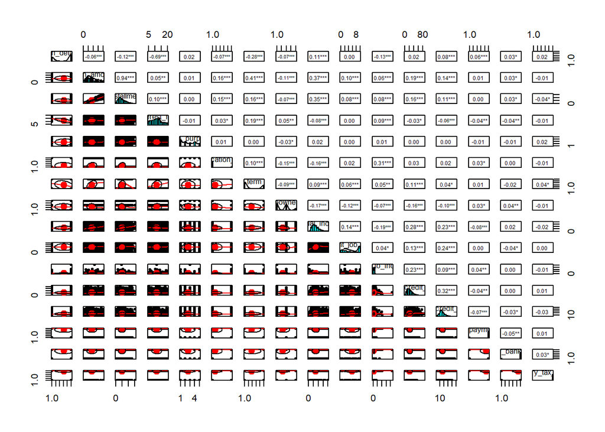

```r
pairs.panels(loan_data,method= "pearson",stars=TRUE)
```

```r
#loan_data= as.numeric(loan_default)
#cor.test(loan_data$loan_default, loan_data$loan_purpose, method=c("kendall"))
#install.packages("gmodels")
library(gmodels)
CrossTable(loan_data$loan_default)
```

```
##
##
##    Cell Contents
## |-------------------------|
## |                       N |
## |         N / Table Total |
## |-------------------------|
##
##
## Total Observations in Table:  4110
##
##
##           |       yes |        no |
##           |-----------|-----------|
##           |      1530 |      2580 |
##           |     0.372 |     0.628 |
##           |-----------|-----------|
##
##
##
##
```

```r
CrossTable(loan_data$history_bankruptcy, loan_data$loan_default, prop.r = TRUE, prop.c = FALSE, prop.t = FALSE, prop.chisq = FALSE)
```

```
##
##
##    Cell Contents
## |-------------------------|
## |                       N |
## |           N / Row Total |
## |-------------------------|
##
##
## Total Observations in Table:  4110
##
##
##                              | loan_data$loan_default
## loan_data$history_bankruptcy |       yes |        no | Row Total |
## -----------------------------|-----------|-----------|-----------|
##                          yes |       203 |       283 |       486 |
##                              |     0.418 |     0.582 |     0.118 |
## -----------------------------|-----------|-----------|-----------|
##                           no |      1327 |      2297 |      3624 |
##                              |     0.366 |     0.634 |     0.882 |
## -----------------------------|-----------|-----------|-----------|
##                 Column Total |      1530 |      2580 |      4110 |
## -----------------------------|-----------|-----------|-----------|
##
##
```

```r
##
```

```r
which(is.na(loan_data$loan_amount))
```

```
## integer(0)
```

##Data Analysis

We will first look at the distributions of and between some characteristics of the loan or the borrower of the loan. This will help us determine which predictor variables may have interesting patterns.

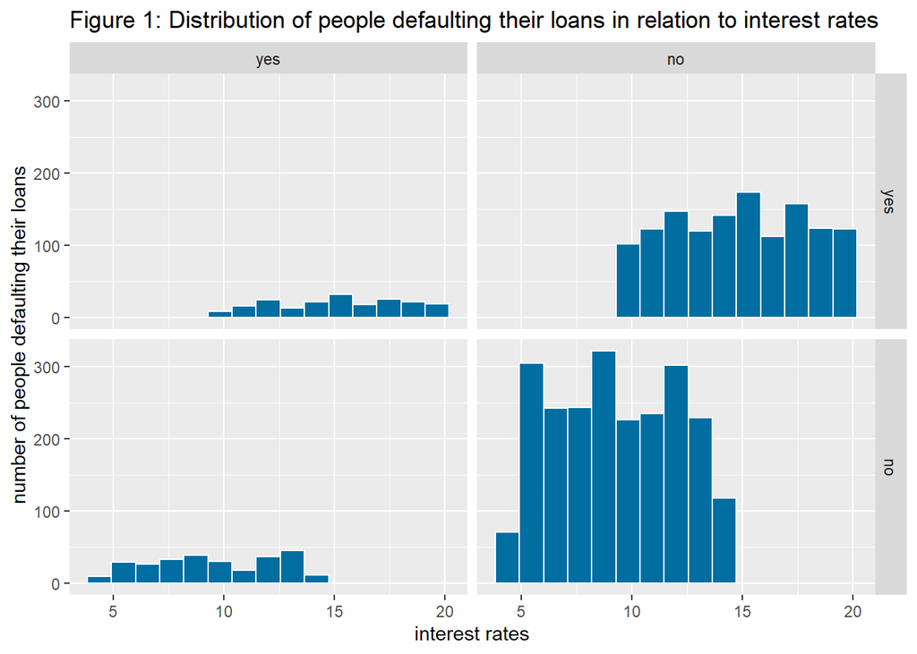

```r
library(ggplot2)
ggplot(data = loan_data, mapping = aes(x = interest_rate)) +
geom_histogram(fill = "#006EA1", color = "white", bins = 15) +
labs(title = "Figure 1: Distribution of people defaulting their loans in relation to interest rates", x =
"interest rates", y = "number of people defaulting their loans")+facet_grid(loan_default ~ history_bankruptcy)
```

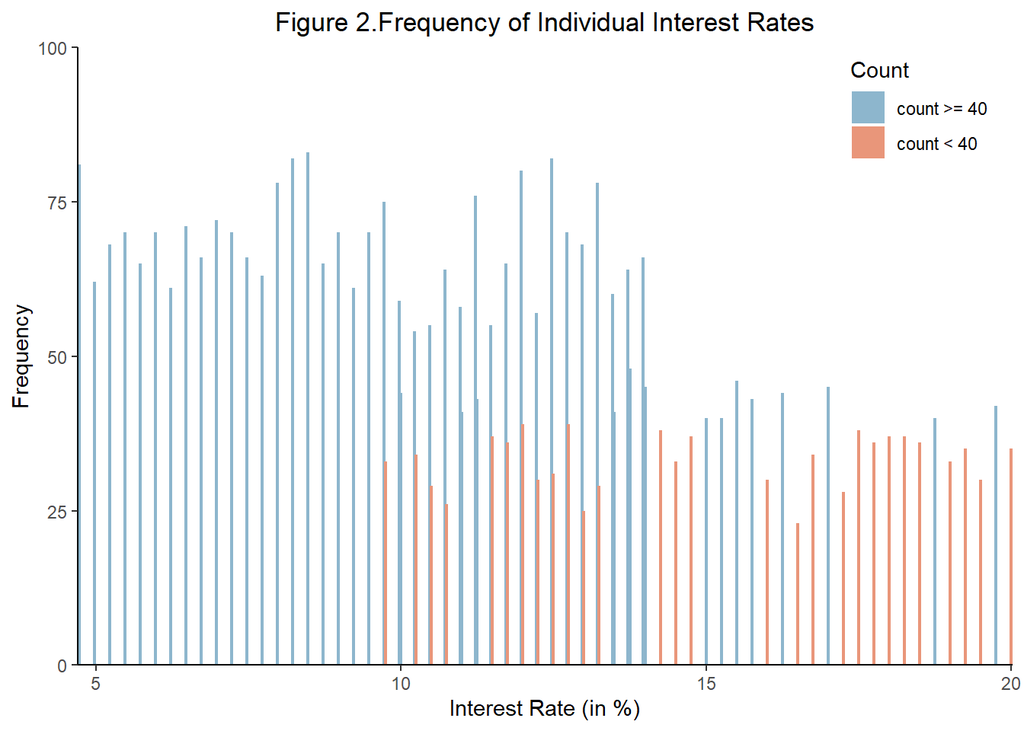

```r
loan_data %>% group_by(interest_rate) %>% summarise(count = n()) %>% ggplot() +
    geom_col(aes(x = interest_rate, y = count, fill = count >= 40), width = 0.05) +
# fill colors
    scale_fill_manual(values = c("darksalmon", "lightskyblue3"), labels = c("count < 40", "count >= 40"),
                     guide = guide_legend(reverse=TRUE)) +
# theme
    theme_classic() + theme(plot.title = element_text(hjust = 0.5), legend.position = c(0.9, 0.9)) +
# labels
    labs(x = "Interest Rate (in %)", y = "Frequency",
         title = "Figure 2.Frequency of Individual Interest Rates", fill = "Count") +
# scales
    scale_x_continuous(expand = c(0,0)) +
    scale_y_continuous(expand = c(0,0), limits = c(0, 100))
```

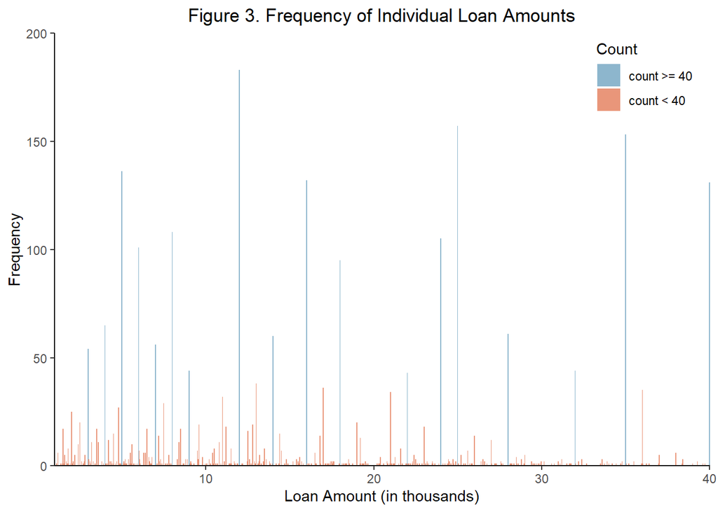

```r
loan_data %>% group_by(loan_amount) %>% summarise(count = n()) %>% ggplot() +
    geom_col(aes(x = loan_amount, y = count, fill = count >= 40), width = 50) +
# fill colors
    scale_fill_manual(values = c("darksalmon", "lightskyblue3"), labels = c("count < 40", "count >= 40"),
                     guide = guide_legend(reverse=TRUE)) +
# theme
    theme_classic() + theme(plot.title = element_text(hjust = 0.5), legend.position = c(0.9, 0.9)) +
# labels
    labs(x = "Loan Amount (in thousands)", y = "Frequency",
         title = "Figure 3. Frequency of Individual Loan Amounts", fill = "Count") +
# scales
    scale_x_continuous(expand = c(0,0), labels = seq(0, 40, 10)) +
    scale_y_continuous(expand = c(0,0), limits = c(0, 200))
```

From the above two graphs, it is interesting to note that the values of interest rate and loan amount have varied frequency, with some values occurring over 40 times in the dataset and others occurring only once. This is probably because some interest rates and amounts are more popular as parts of standard loan pacakges.

[figure not shown]

```r
#str(loan_data)
loan_data %>% group_by(loan_purpose) %>% summarise(count = n()) %>% ggplot() +
    geom_col(aes(x = reorder(loan_purpose, count), y = count, fill = count<30)) +
# fill colors
    scale_fill_manual(values = c("lightsteelblue", "darksalmon"),
                     labels = c( "count < 30")) +
# theme
    theme_classic() + theme(axis.text.x = element_text(size = 9, angle = 20, hjust = 0.7),
                            plot.title = element_text(hjust = 0.5),
                           legend.position = "bottom") +
# labels
    labs(x = "purpose", y = "Frequency", fill = "Count",
         title = "Distribution of Reasons for Taking Out Loan")
```

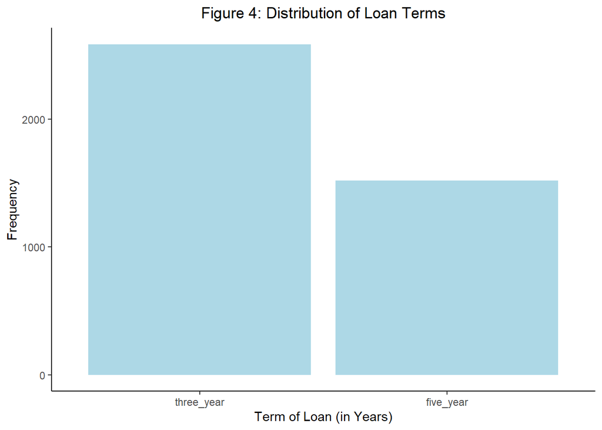

```r
ggplot(data = loan_data, aes(x = term)) +
    geom_bar(position= "dodge",fill= "lightblue") +
# theme
    theme_classic() + theme(plot.title = element_text(hjust = 0.5)) +
# labels
    labs(x = "Term of Loan (in Years)", y = "Frequency",
         title = "Figure 4: Distribution of Loan Terms")
```

In the above first figure it is clear that debt are the most common reasons that borrowers take out loans.This is probably because people take out loans to pay off pre-existing debts or to pay off bills, and there is no high variability between the categories provided.

In the above second figure we get to know that there are far more short-term loans than lon- term loans.

[figure not shown]

```r
clean <- loan_data %>% filter(annual_income < 70000 &  debt_to_income <15 )

clean %>% ggplot(aes(x = annual_income, y = debt_to_income, col = annual_income* 1200 + 9000 < debt_to_income))+
    geom_point(show.legend = FALSE) +geom_smooth(color='black')+
# fill colors
    scale_color_manual(values = c("lightskyblue3", "darksalmon")) +
# theme
    theme_classic() + theme(plot.title = element_text(hjust = 0.5)) +
# labels
    labs(x = "anuual income", y = "debt(in thousands)",
         title = "Figure 5: Relationship between annual income and debt ratio ")
```

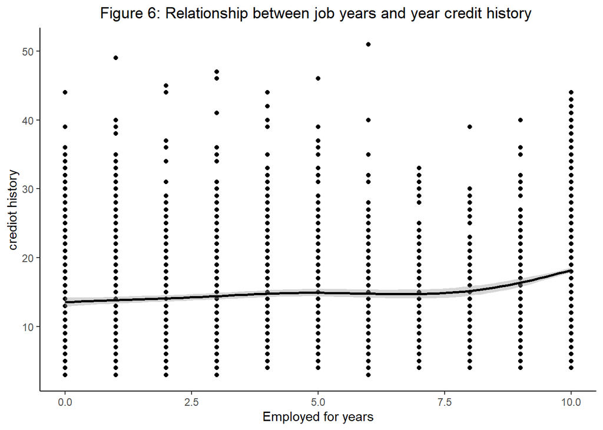

```r
ggplot(data = loan_data, aes(x = current_job_years, y = years_credit_history))+
    geom_point(show.legend = FALSE) +geom_smooth(color='black')+
# fill colors
    scale_color_manual(values = c("lightskyblue3")) +
# theme
    theme_classic() + theme(plot.title = element_text(hjust = 0.5)) +
# labels
    labs(x = "Employed for years", y = "crediot history",
         title = "Figure 6: Relationship between job years and year credit history ")
```

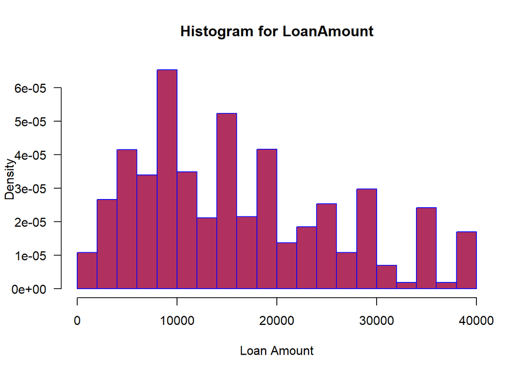

```r
hist(loan_data$loan_amount,
     main="Histogram for LoanAmount",
     xlab="Loan Amount",
     border="blue",
     col="maroon",
     las=1,
     breaks=20, prob = TRUE)
```

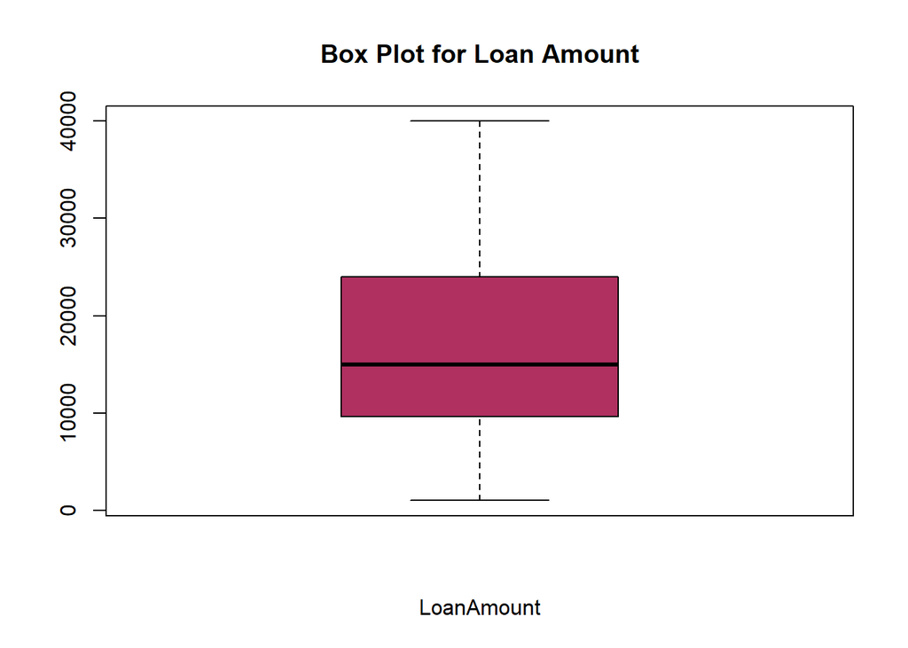

```r
boxplot(loan_data$loan_amount, col='maroon',xlab = 'LoanAmount', main = 'Box Plot for Loan Amount')
```

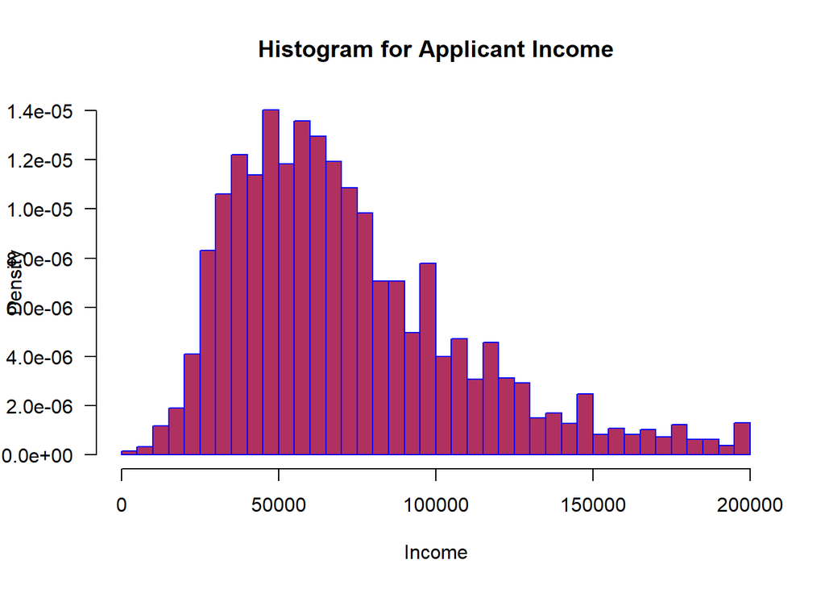

```r
hist(loan_data$annual_income,
     main="Histogram for Applicant Income",
     xlab="Income",
     border="blue",
     col="maroon",
     las=1,
     breaks=50, prob = TRUE)
```

[figure not shown]

```r
boxplot(loan_data$annual_income, col='maroon',xlab = 'LoanAmount', main = 'Box Plot for Loan Amount')
```

```r
data(loan_data, package="lattice")
```

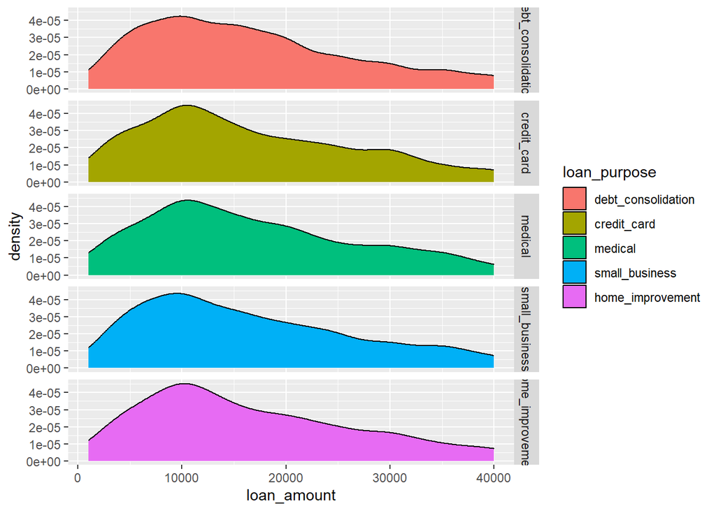

```r
ggplot(data=loan_data, aes(x=loan_amount, fill=loan_purpose)) +
  geom_density() +
  facet_grid(loan_purpose~.)
```

```r
data(loan_data, package="lattice")
```

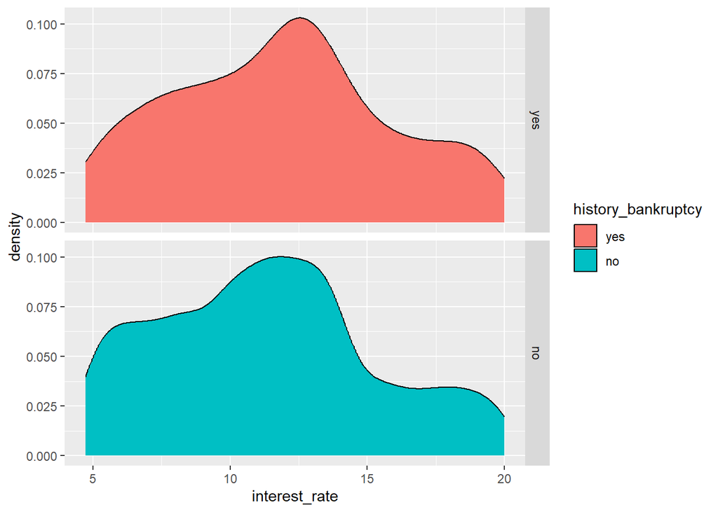

```r
ggplot(data=loan_data, aes(x=interest_rate, fill=history_bankruptcy)) +
  geom_density() +
  facet_grid(history_bankruptcy~.)
```

#Q) Create a histogram to visualize the distribution of loan amounts for default and non-default customers

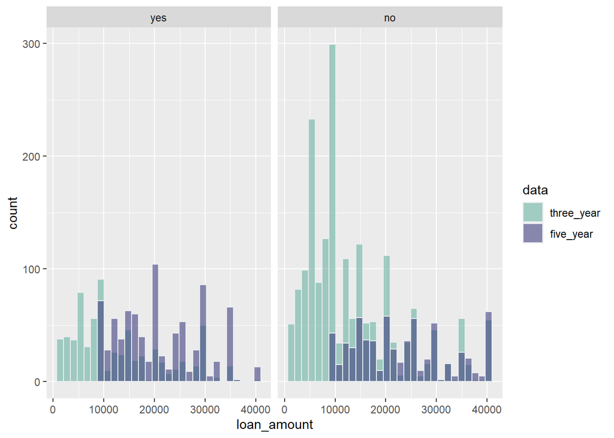

```r
ggplot(loan_data, aes(x = loan_amount, fill = term)) +
  geom_histogram(color="#e9ecef",alpha=0.6, position = 'identity') +
  scale_fill_manual(values=c("#69b3a2", "#404080")) +
    labs(fill="data")+facet_wrap(~loan_default)
```

#Q.Are there any differences in loan default rates and loan amount by annual income?

```r
loan_data$loan_default <- as.numeric(unlist(loan_data$loan_default))
loan_data$loan_amount <- as.numeric(loan_data$loan_amount)

default_by_income <-loan_data%>%
  group_by(loan_default, loan_amount, annual_income,loan_purpose)%>%
  summarise(n_customers = n(),
  customers_default = sum(loan_default == "Yes"),
  default_percent = 100 * mean(loan_default == "Yes"))
```

[output not shown]

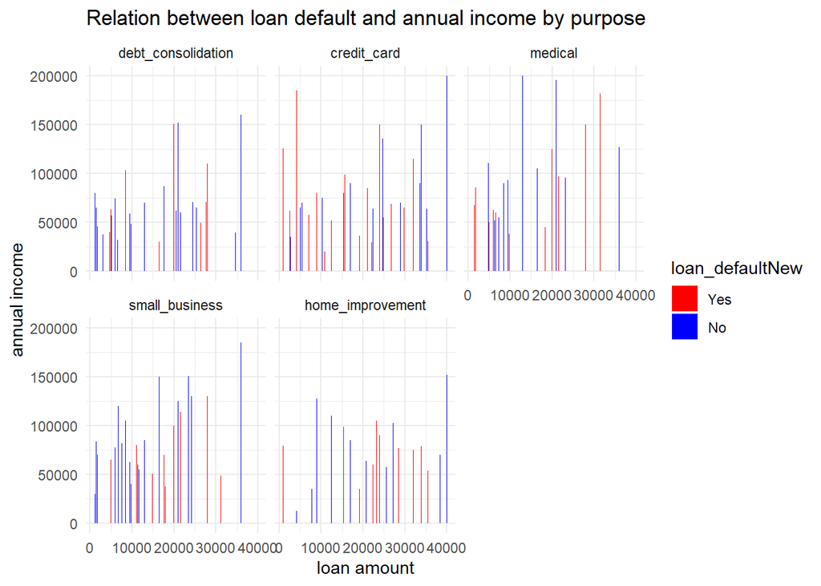

```r
default_by_income$loan_defaultNew <- cut(default_by_income$loan_default, breaks = 2, labels = c("Yes", "No"))




ggplot(default_by_income, aes(x= loan_amount, y= annual_income, fill= loan_defaultNew))+
  geom_bar(stat ="identity", position = position_dodge())+
  labs(title = "Relation between loan default and annual income by purpose", x="loan amount", y= "annual income") + scale_fill_manual(values = c("No" = "blue", "Yes"= "Red"))+
  theme_minimal()+facet_wrap(~loan_purpose)
```

#Q. What is the relationship between loan default, application type and interest rate?

```r
# Group the data by 'loan_default' and 'application_type'
#install.packages("virdis")
library(viridis)
default_applicationtype<- loan_data %>%
  group_by(loan_default, application_type,loan_purpose) %>%
  summarize(mean_interest_rate = mean(interest_rate))
```

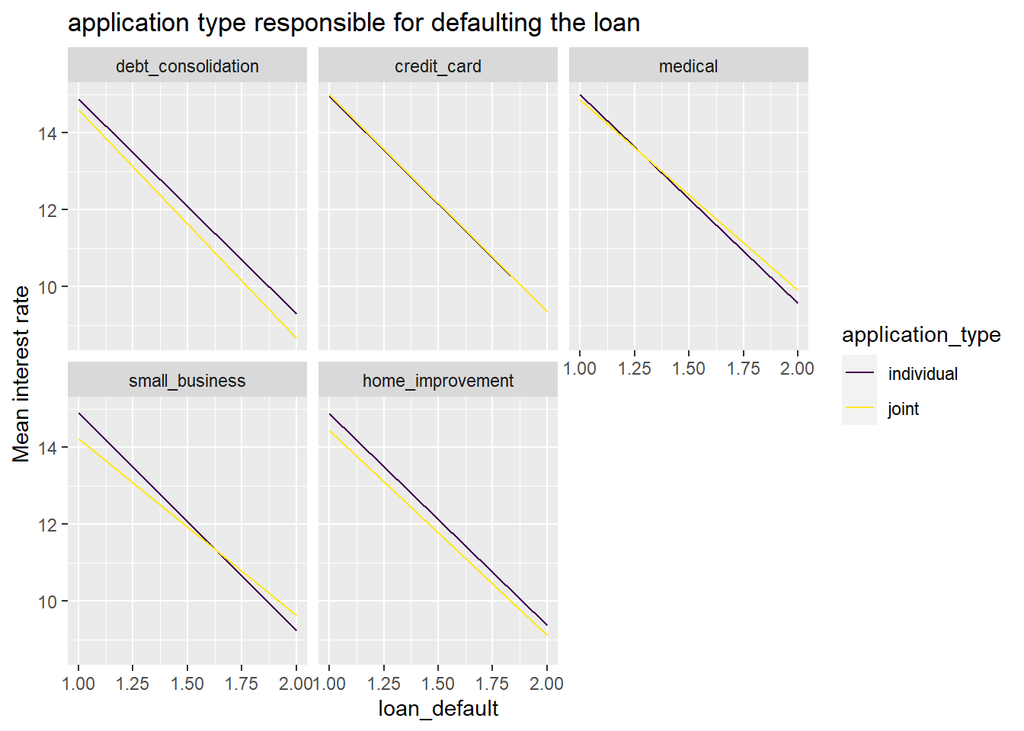

```r
ggplot(default_applicationtype, aes(x = loan_default, y = mean_interest_rate, group = application_type,color = application_type)) +
  geom_line() +scale_color_viridis(discrete = TRUE)+
  ggtitle("application type responsible for defaulting the loan")+ ylab("Mean interest rate")+facet_wrap(~loan_purpose)
```

#Q) Find out the relationship between credit history and loan default by missed payments

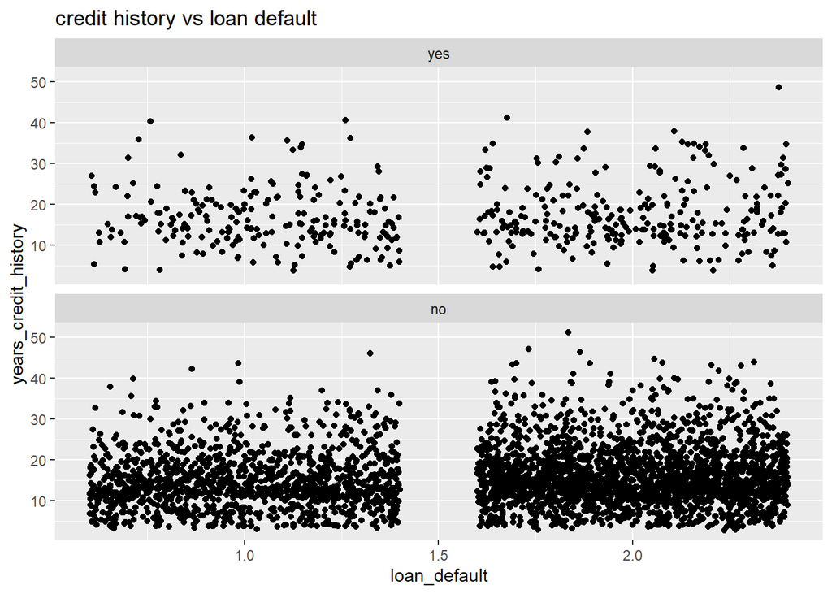

```r
ggplot(data = loan_data, mapping = aes(x = loan_default, y = years_credit_history)) +
geom_jitter() + facet_wrap(~ missed_payment_2_yr, nrow = 2)+labs(title = "credit history vs loan default")
```

#Q)Create a scatter plot to explore the relationship between the number of open accounts and loan default

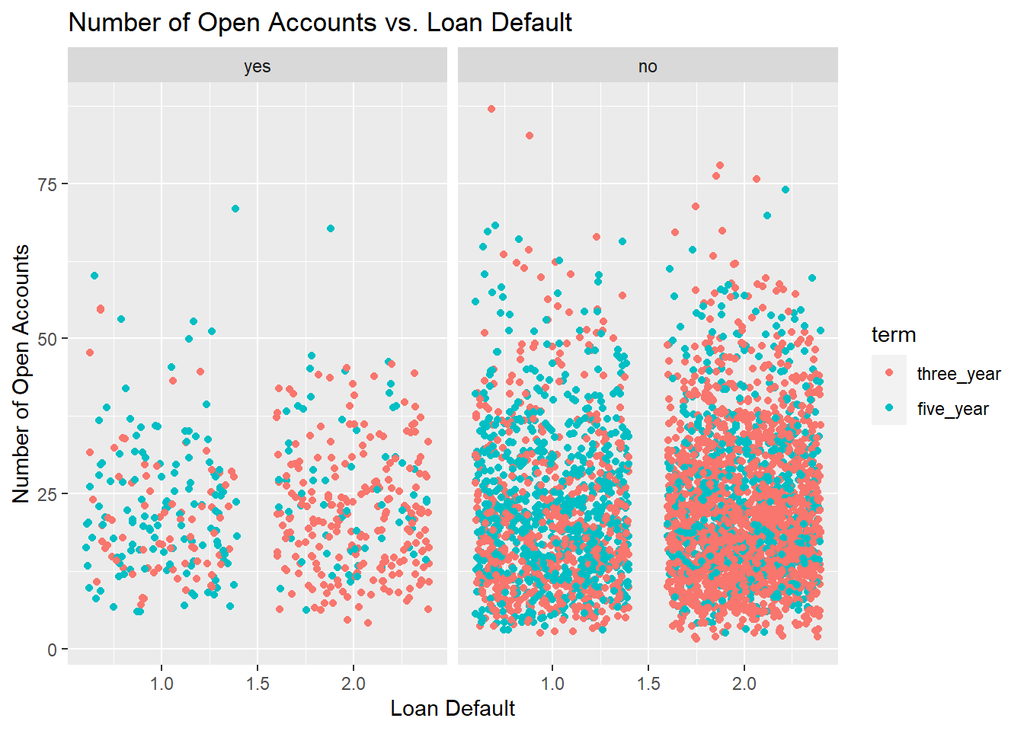

```r
ggplot(loan_data, aes(y = total_credit_lines, x = loan_default, color = term)) +
  geom_jitter() +
  labs(title = "Number of Open Accounts vs. Loan Default", y = "Number of Open Accounts", x = "Loan Default")+facet_grid(~ history_bankruptcy)
```